# Data analysis *Testgenauigkeit Bayes* from exercise session *Stochastik und ind. Statistik* (Master Wirtschaftsinformatik) / Nov 15 2023

Markus Konrad

2023-11-16

## Preparation

### Load data, helper functions

```r
source("analysis_helpers.R")

tracking_data <- readRDS("data/prepared/f33ac92fb8_tracking_data.rds")
```

### Tracking session duration

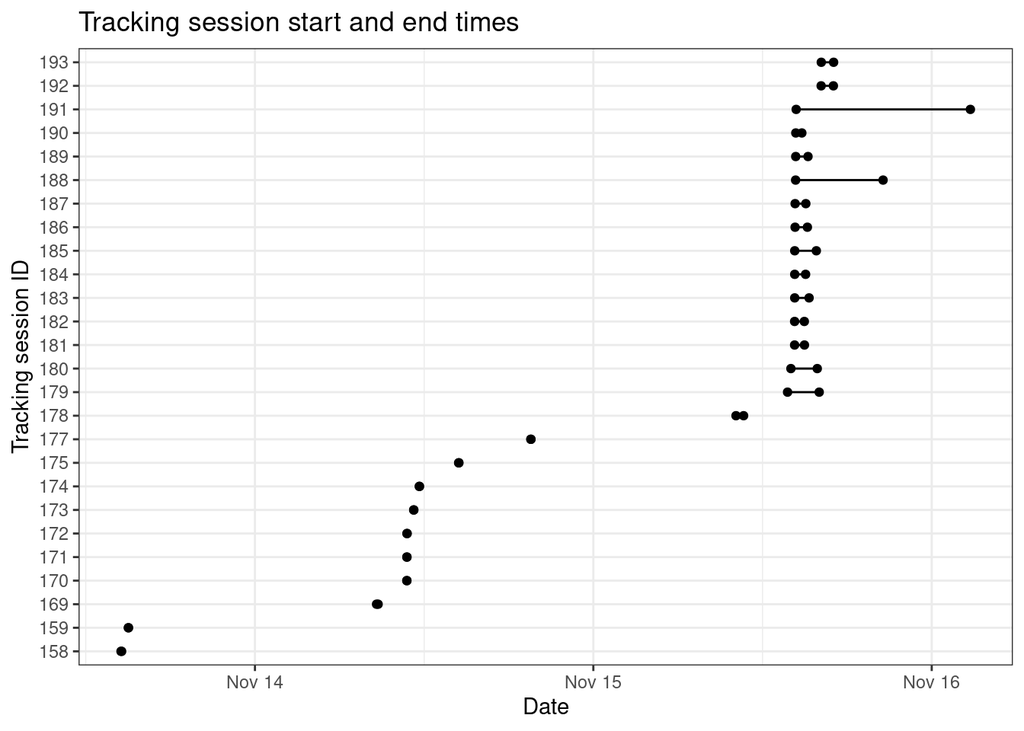

```r
track_sess_times <- tracking_sess_times(tracking_data)

plot_tracking_sess_durations(track_sess_times)
```

### Limit tracking session events to exercise time frame

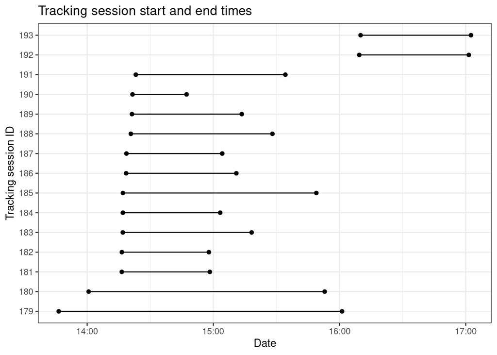

```r
starttime <- strptime("2023-11-15 13:15", "%Y-%m-%d %H:%M")    # exercise start - 30 min.
endtime <- strptime("2023-11-15 17:30", "%Y-%m-%d %H:%M")      # exercise end + 30 min.

tracking_data <- filter(tracking_data, event_time >= starttime, event_time <= endtime) |>
    group_by(track_sess_id) |>
    mutate(track_sess_start = min(track_sess_start, min(event_time)),
           track_sess_end = min(track_sess_end, max(event_time))) |>
    ungroup()

track_sess_times <- tracking_sess_times(tracking_data)

plot_tracking_sess_durations(track_sess_times)
```

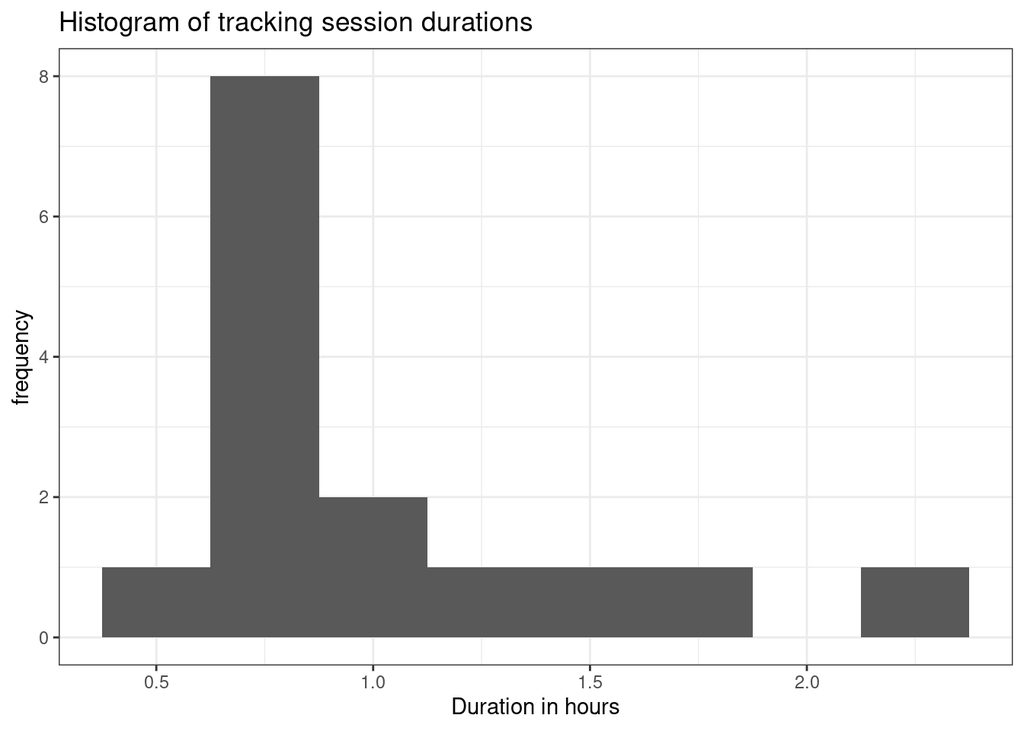

```r
plot_tracking_sess_durations_hist(track_sess_times, binwidth = 0.25)
```

- long interaction time

```r
median(track_sess_times$duration) |> as.double(units = "mins")
```

```
## [1] 52.37408
```

### Number of observations, unique users and event types

- many observations

```r
dim(tracking_data)
```

```
## [1] 260265     38
```

- number of unique users:

```r
length(unique(tracking_data$user_app_sess_code))
```

```
## [1] 15
```

- each user created only one tracking session:

```r
length(unique(tracking_data$track_sess_id))
```

```
## [1] 15
```

- one user used a tablet, all others a laptop or desktop PC:

```r
group_by(tracking_data, track_sess_id) |>
    distinct(form_factor) |>
    ungroup() |>
    count(form_factor)
```

```
## # A tibble: 2 × 2
##   form_factor     n
##   <fct>       <int>
## 1 desktop        14
## 2 tablet          1
```

- number of events per event type:

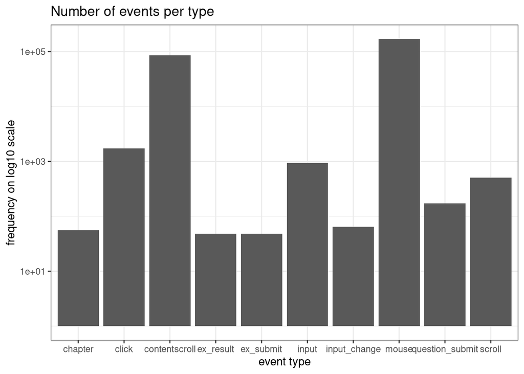

```r
res <- plot_event_type_counts(tracking_data)
res$plot
```

```r
res <- plot_event_type_counts(tracking_data)
res$table
```

```
## # A tibble: 10 × 2
##    type                 n
##    <fct>            <int>
##  1 chapter             56
##  2 click             1728
##  3 contentscroll    86469
##  4 ex_result           48
##  5 ex_submit           48
##  6 input              944
##  7 input_change        65
##  8 mouse           170226
##  9 question_submit    173
## 10 scroll             508
```

- number of events per event type in each tracking session:

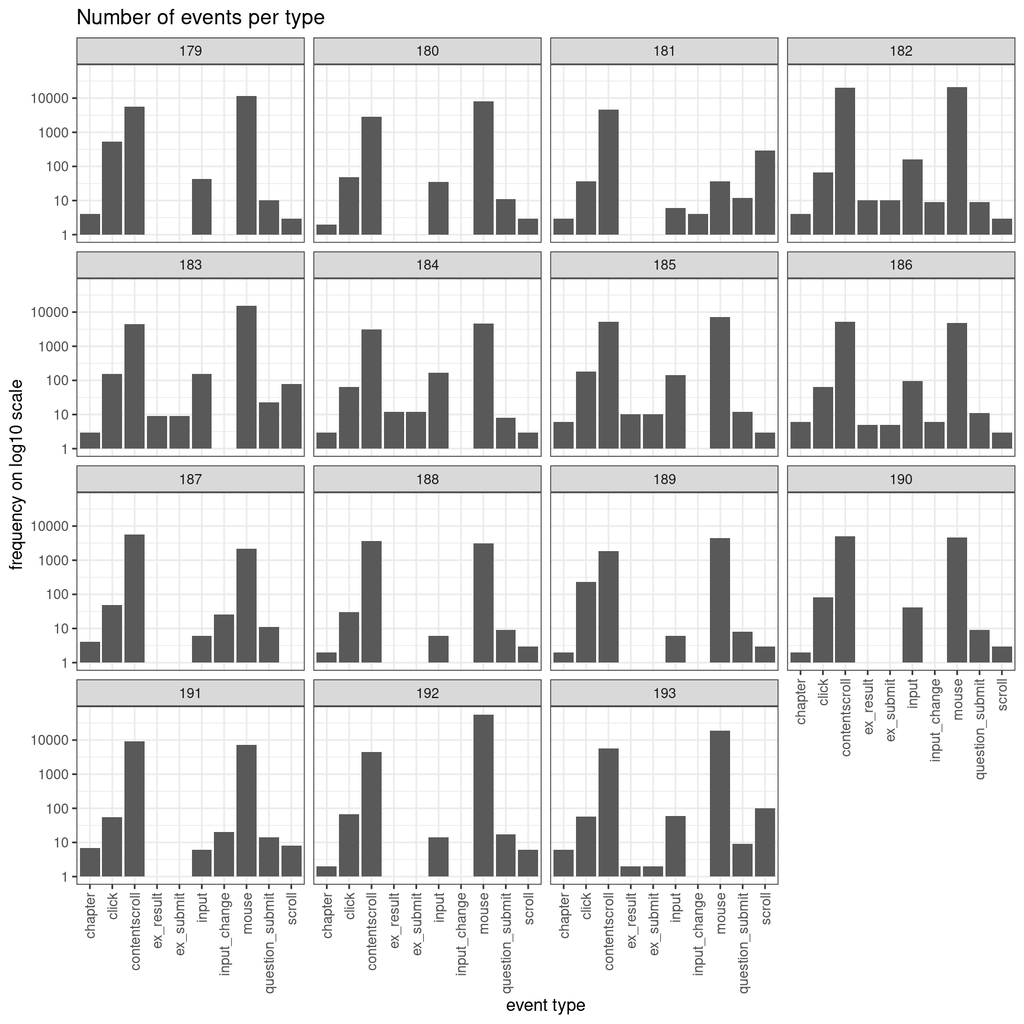

```r
res <- plot_event_type_counts_per_tracking_sess(tracking_data)
res$plot
```

- some students apparently did not submit code exercises, but all submitted answers on questions

```r
submit_event_counts <- filter(res$table, type %in% c("ex_result", "ex_submit", "question_submit")) |>
    pivot_wider(names_from = type, values_from = n, values_fill = 0)
submit_event_counts
```

```
## # A tibble: 15 × 4
##    track_sess_id question_submit ex_result ex_submit
##            <int>           <int>     <int>     <int>
##  1           179              10         0         0
##  2           180              11         0         0
##  3           181              12         0         0
##  4           182               9        10        10
##  5           183              23         9         9
##  6           184               8        12        12
##  7           185              12        10        10
##  8           186              11         5         5
##  9           187              11         0         0
## 10           188               9         0         0
## 11           189               8         0         0
## 12           190               9         0         0
## 13           191              14         0         0
## 14           192              17         0         0
## 15           193               9         2         2
```

```r
mutate(submit_event_counts, ex = ex_result + ex_submit) |>
    select(-c(ex_result, ex_submit)) |>
    filter(question_submit == 0 | ex == 0)
```

```
## # A tibble: 9 × 3
##   track_sess_id question_submit    ex
##           <int>           <int> <int>
## 1           179              10     0
## 2           180              11     0
## 3           181              12     0
## 4           187              11     0
## 5           188               9     0
## 6           189               8     0
## 7           190               9     0
## 8           191              14     0
## 9           192              17     0
```

### Question and code exercise submissions

- proportion of correct answers per question:

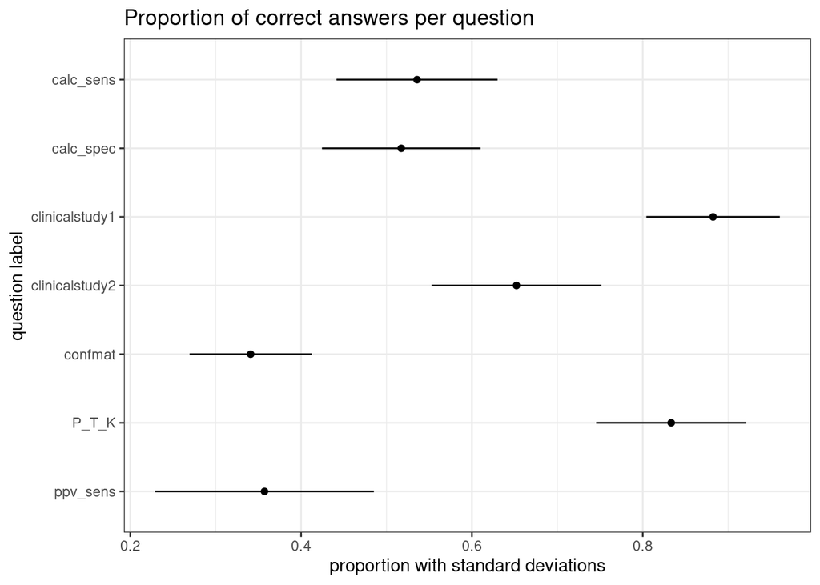

```r
quest_data <- question_submit_data(tracking_data)
res <- plot_question_prop_correct(quest_data)
res$plot
```

```r
res$table
```

```
## # A tibble: 7 × 4
##   ex_label           n prop_correct sd_correct
##   <fct>          <int>        <dbl>      <dbl>
## 1 calc_sens         28        0.536     0.0942
## 2 calc_spec         29        0.517     0.0928
## 3 clinicalstudy1    17        0.882     0.0781
## 4 clinicalstudy2    23        0.652     0.0993
## 5 confmat           44        0.341     0.0715
## 6 P_T_K             18        0.833     0.0878
## 7 ppv_sens          14        0.357     0.128
```

- number of tries per question:

```r
quiz_tries <- question_or_exercise_submit_tries(quest_data)
```

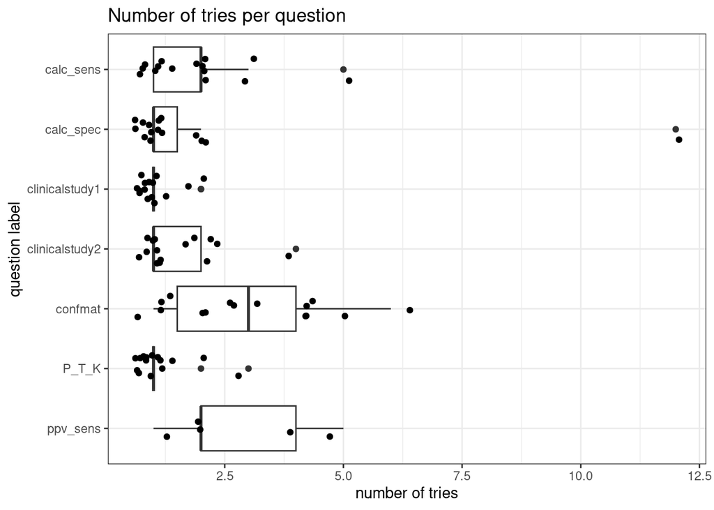

```r
plot_question_n_tries(quiz_tries)
```

- interestingly, each question was finally answered correctly – no one gave up in between:

```r
all(quiz_tries$ex_correct)
```

```
## [1] TRUE
```

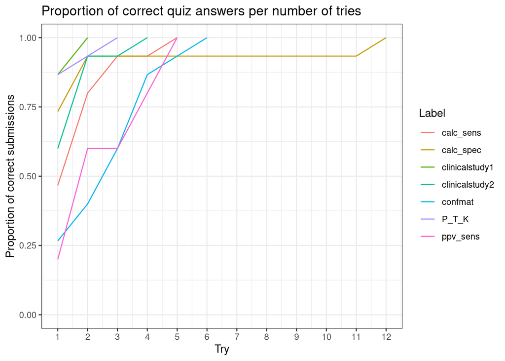

```r
quiz_prop_correct_per_try <- prop_correct_in_ith_try(quest_data)
plot_prop_correct_per_try(quiz_prop_correct_per_try, "Proportion of correct quiz answers per number of tries")
```

- only a few coding exercises were tried, and even fewer succeeded

```r
ex_data <- exercise_result_data(tracking_data)
ex_tries <- question_or_exercise_submit_tries(ex_data)
group_by(ex_tries, ex_label) |>
    summarise(n = n(),
              prop_correct = mean(ex_correct))
```

```
## # A tibble: 2 × 3
##   ex_label           n prop_correct
##   <fct>          <int>        <dbl>
## 1 neg_pred_value     6        0.167
## 2 nvw_a              1        1
```

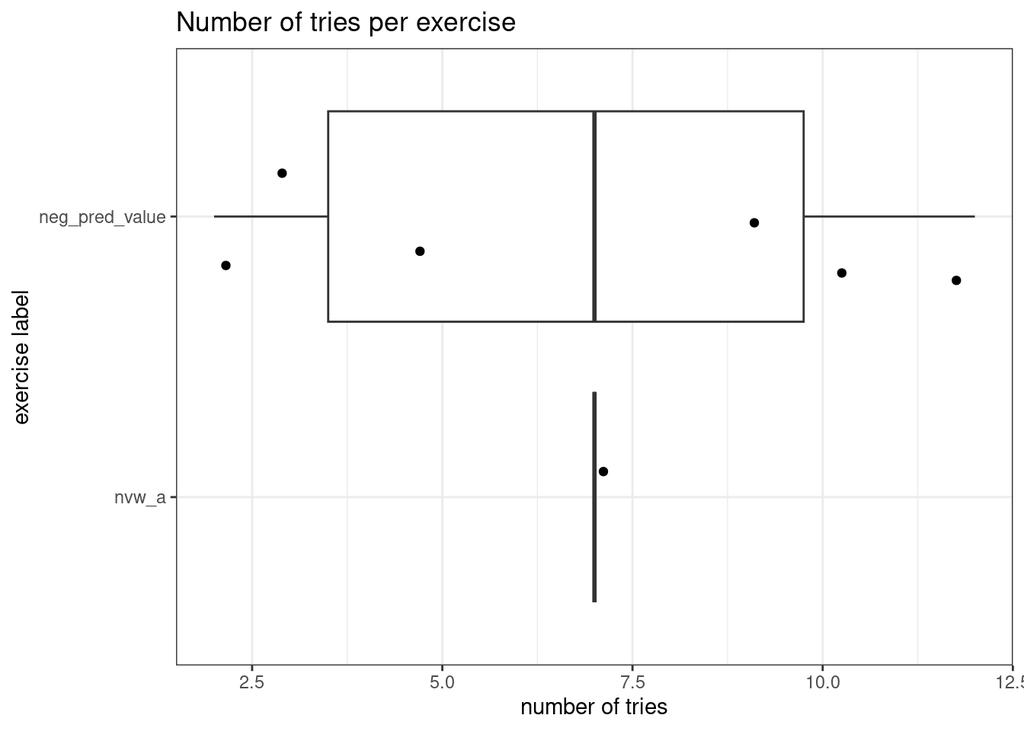

```r
plot_exercise_n_tries(ex_tries)
```

- all in all less then a third of the exercise were answered correctly in the end, means most students gave up

```r
mean(ex_tries$ex_correct)
```

```
## [1] 0.2857143
```

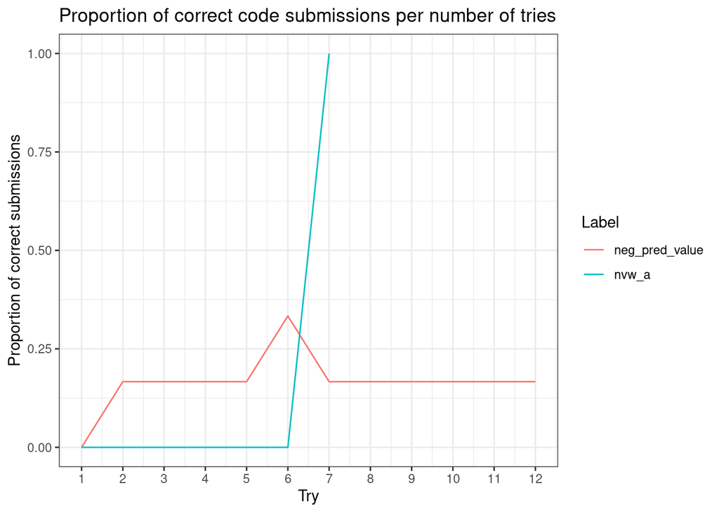

```r
ex_prop_correct_per_try <- prop_correct_in_ith_try(ex_data)
plot_prop_correct_per_try(ex_prop_correct_per_try, "Proportion of correct code submissions per number of tries")
```

- (on try 6, someone in tracking session #185 made a correct submission and then regressed to a wrong submission afterwards)
- often, the submitted code is not correct R code
- furthermore, students don’t understand that the last output is the result but assume that the have to use `print(...)` to return the result

```r
filter(ex_data, !ex_correct) |>
    pull(value) |>
    trimws() |>
    paste(collapse = "\n---\n") |>
    cat()
```

```
## prevalence = 0,02
## sens = 0,914
## spec = 0,994
##
## positiveIll = (sens * prevalence)/(sens*prevalence + (1 - spec)*(1 - prevalence))
## print(positiveIll)
## ---
## prevalence = 0.02
## sens = 0.914
## spec = 0.994
##
## positiveIll = (sens * prevalence)/(sens*prevalence + (1 - spec)*(1 - prevalence))
## print(positiveIll)
## ---
## prevalence = 0.02
## sens = 0.914
## spec = 0.994
##
## positiveIll = (sens * prevalence)/(sens*prevalence + (1 - spec)*(1 - prevalence))
## print(1-positiveIll)
## ---
## prevalence = 0.002
## sens = 0.914
## spec = 0.994
##
## positiveIll = (sens * prevalence)/(sens*prevalence + (1 - spec)*(1 - prevalence))
## print(1-positiveIll)
## ---
## prevalence = 0.002
## sens = 0.914
## spec = 0.994
##
## positiveIll = (sens * prevalence)/(sens*prevalence + (1 - spec)*(1 - prevalence))
## print(positiveIll)
## ---
## prevalence = 0.002
## sens = 0.914
## spec = 0.994
##
## positiveIll = (sens * prevalence)/(sens*prevalence + (1 - spec)*(1 - prevalence))
```

[output cut: 196 more lines]

```
## (1-prevalence)*(1-spec) / ((1-prevalence)*(1-spec))+(1-sens*spec)
## ---
## sens
## spec
## prevalence
##
## ntk <- 1 - sens
## ntk
##
## nk <- 1 - spec
## nk
##
## (1-prevalence)*(1-spec) / ((1-prevalence)*(1-spec))+(1-sens*spec)
## ---
## (0.994*0.998)/((0.994*0.998)+(1-0.914)*0.002)
```

### Mouse tracks

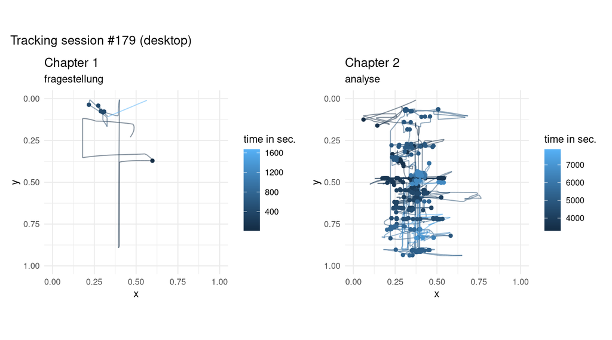

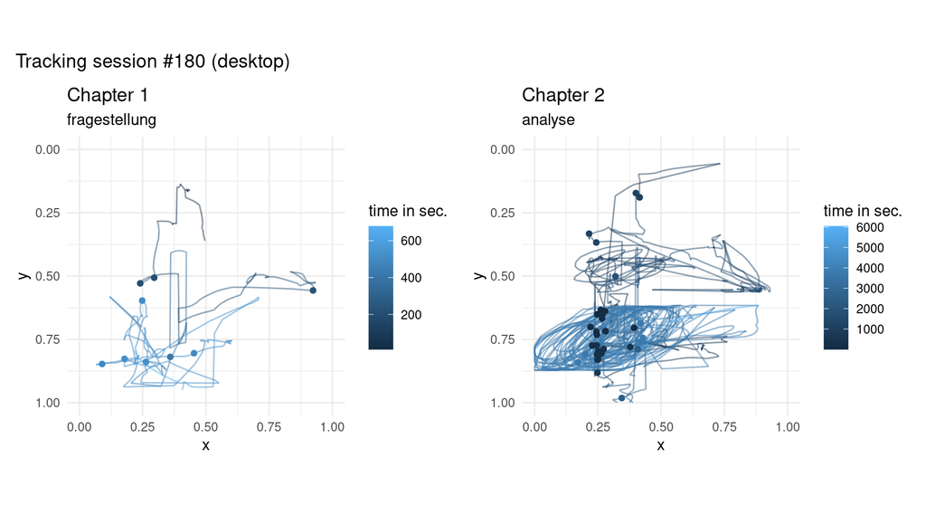

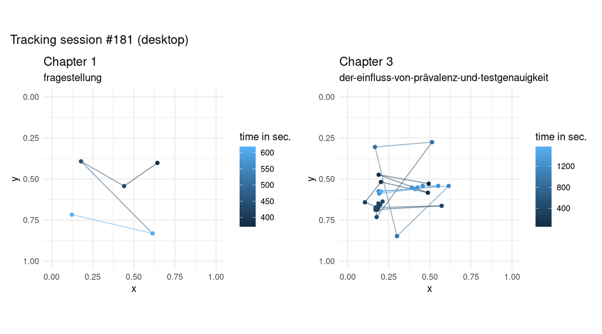

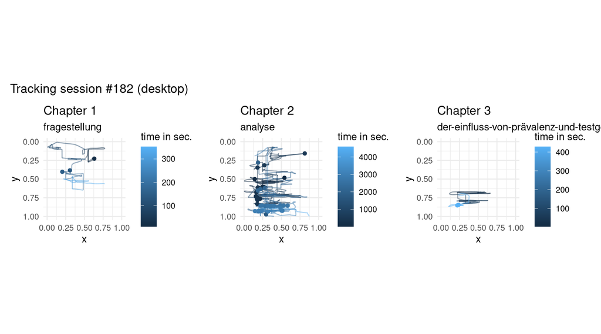

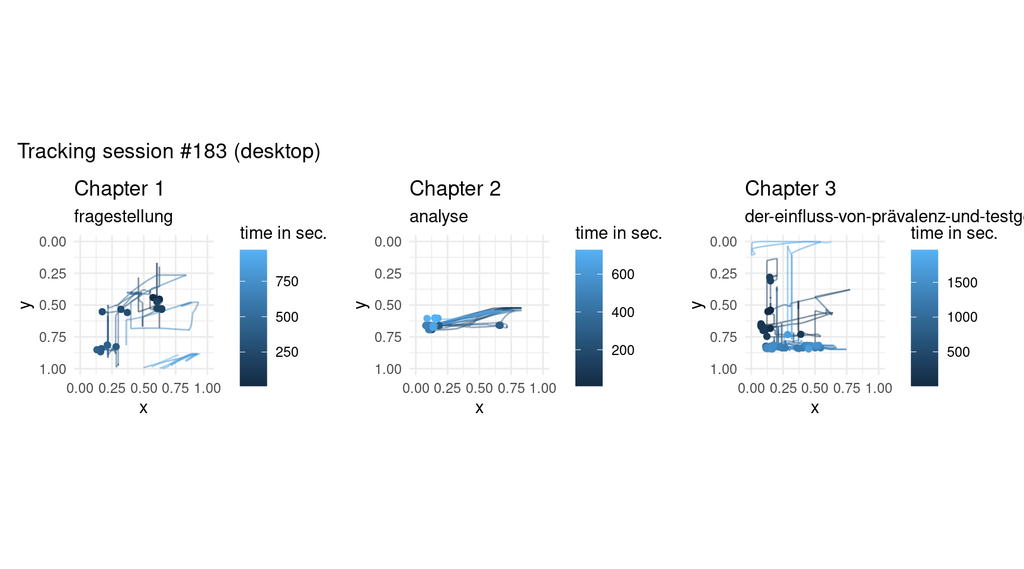

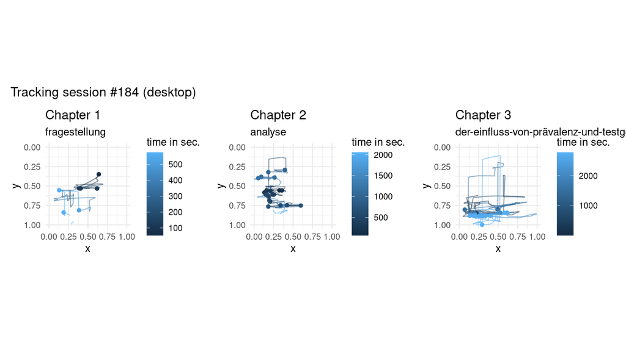

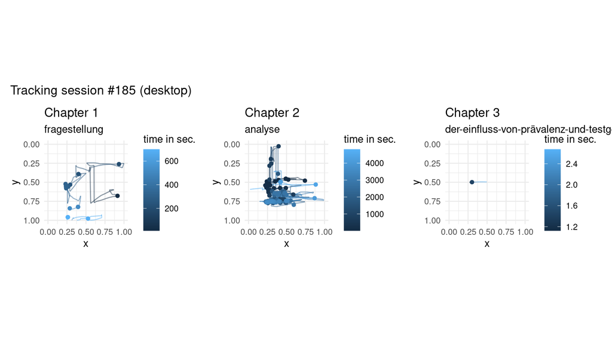

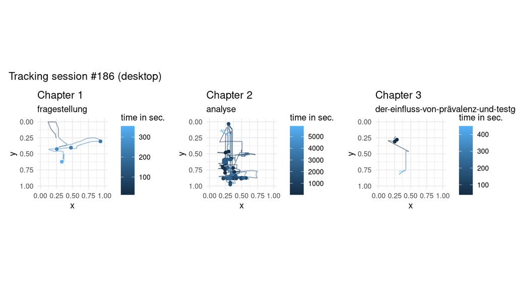

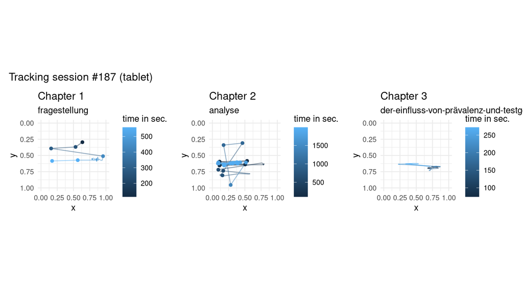

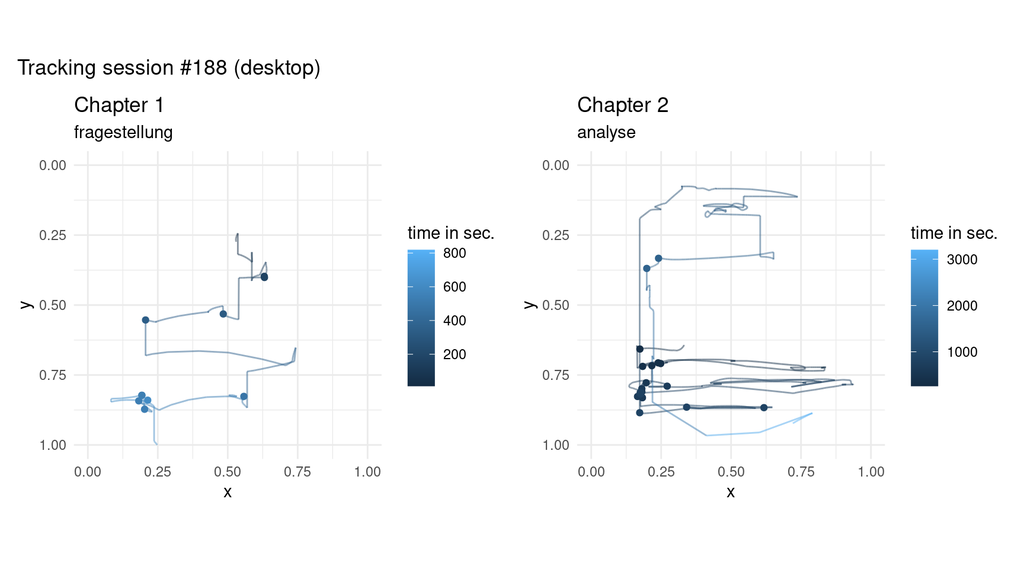

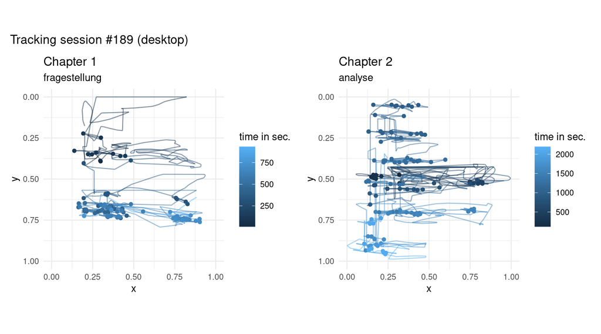

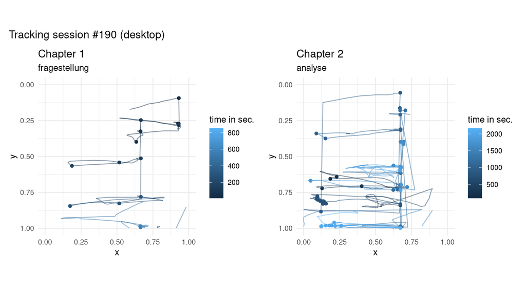

[3 more figures not shown]

```r
for (track_sess_id in sort(unique(tracking_data$track_sess_id))) {
    print(plot_mouse_tracks_for_tracking_session(tracking_data, track_sess_id))
}
```